# Презентация по разделу №3 ‘Криптография на практике’ внешнего курса на тему ‘Основы кибербезопасности’

Основы информационной безопасности

Татьяна Александровна Пономарева

Российский университет дружбы народов

2026-04-29

# Информация

## Докладчик

*Пономарева Татьяна Александровна* Студент группы НКАбд-04-24 *Российский университет дружбы народов им. П. Лумумбы* taponomareva6742@gmail.com *https://github.com/taponomareva

# Вводная часть

## Цель работы

Выполнить задания раздела 3 и понять, что входит в криптографию на практике.

## Теоретическое введение

Данный курс рассчитан на любого пользователя ПК/смартфона/банкомата и состоит из 3-х разделов, также он содержит лекции, материалы для доп. чтения и тесты [1].

# Выполнение заданий раздела 3 “Криптография на практике”

## Введение в криптографию. Наличие ключей у обоих сторон

В асимметричных криптографических примитивах обе стороны имеют пару ключей (рис. 1).

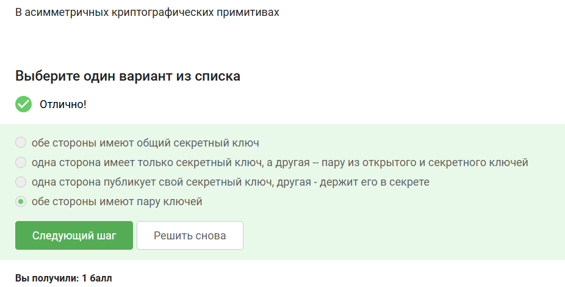

Рисунок 1: Наличие ключей у обоих сторон

## Свойства криптографической хэш-функции

Криптографическая хэш-функция эффективно вычисляется, дает на выходе фиксированное число бит независимо от объема данных и стойкая к коллизиям (рис. 2).

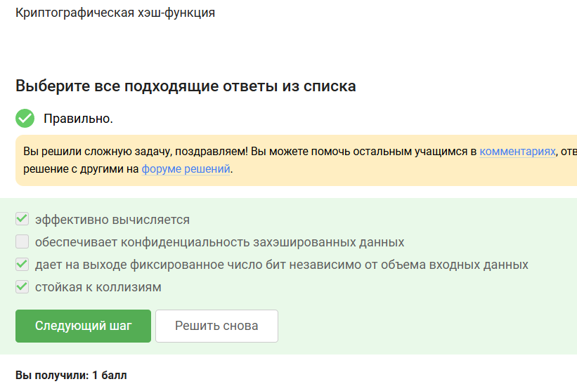

Рисунок 2: Свойства криптографической хэш-функции

## Алгоритмы цифровой подписи

К алгоритмам цифровой подписи относятся RSA, ECDSA, ГОСТ Р 34.10-2012 (рис. 3).

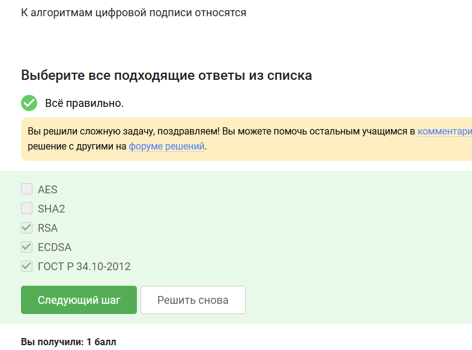

Рисунок 3: Алгоритмы цифровой подписи

## Код аутентификации сообщения

Код аутентификации сообщения относится к симметричным примитивам (рис. 4).

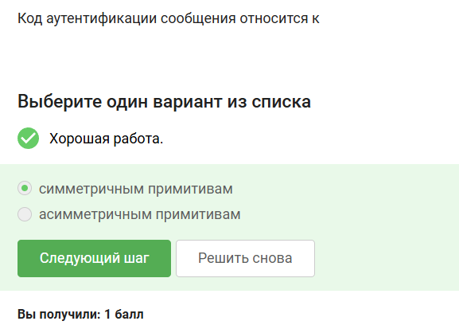

Рисунок 4: Код аутентификации сообщения

## Обмен ключами Диффи-Хэллмана

Обмен ключами Диффи-Хэллмана - это асимметричный примитив генерации общего секретного ключа (рис. 5).

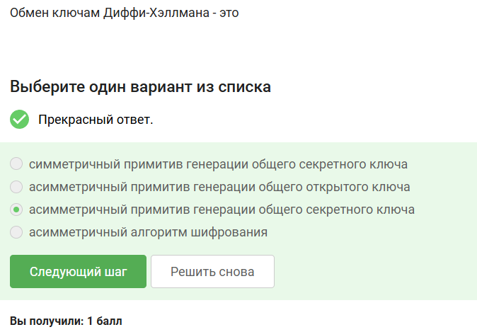

Рисунок 5: Обмен ключами Диффи-Хэллмана

## Цифровая подпись. Протокол электронной подписи

Протокол электронной подписи относится к протоколам с публичным (или открытым) ключом (рис. 6).

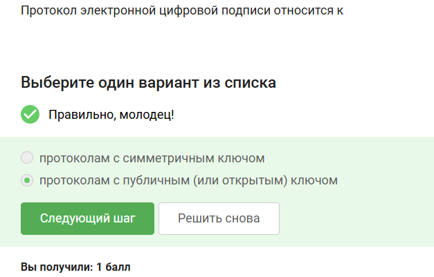

Рисунок 6: Протокол электронной подписи

## Требования алгоритма верификации электронной подписи

Алгоритм верификации электронной подписи требует на вход подпись, открытый ключ, сообщение (рис. 7).

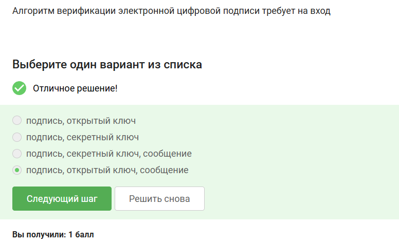

Рисунок 7: Требования алгоритма верификации электронной подписи

## Электронная цифровая подпись и конфиденциальность

Электронная цифровая подпись не обеспечивает конфиденциальность (рис. 8).

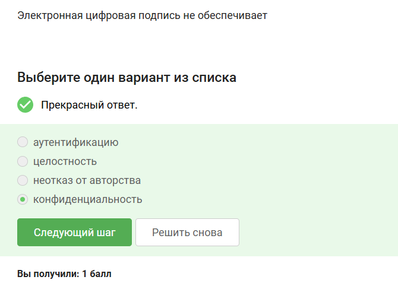

Рисунок 8: Электронная цифровая подпись и конфиденциальность

## Тип сертификата электронной подписи для отправки налоговой отчетности в ФНС

Усиленный квалифицированный тип сертификата электронной подписи понадобится для отправки налоговой отчетности в ФНС (рис. 9).

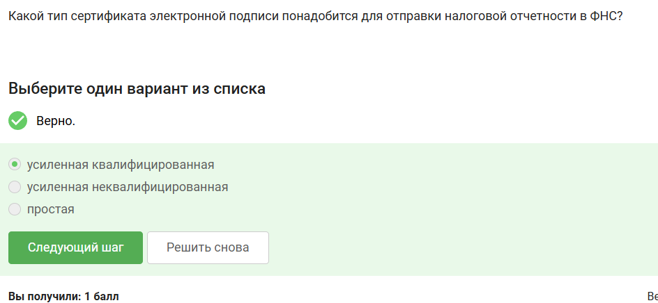

Рисунок 9: Тип сертификата электронной подписи для отправки налоговой отчетности в ФНС

## Организация для получения квалифицированного сертификата ключа проверки электронной подписи

В удостоверяющем (сертификационном) центре можно получить квалифицированный сертификат ключа проверки электронной подписи (рис. 10).

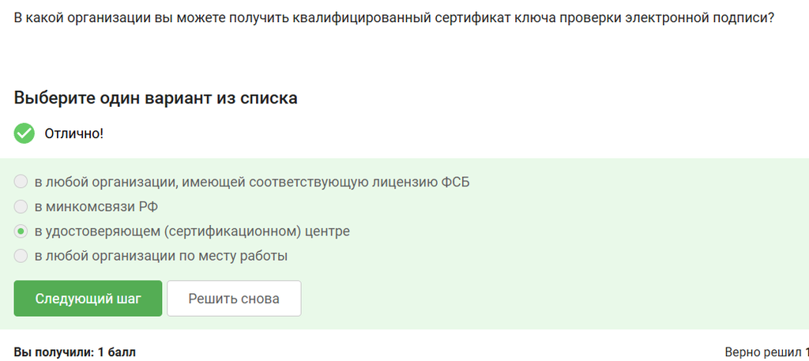

Рисунок 10: Организация для получения квалифицированного сертификата ключа проверки электронной подписи

## Электронные платежи. Платежные системы

Платежные системы: MasterCard, МИР (рис. 11).

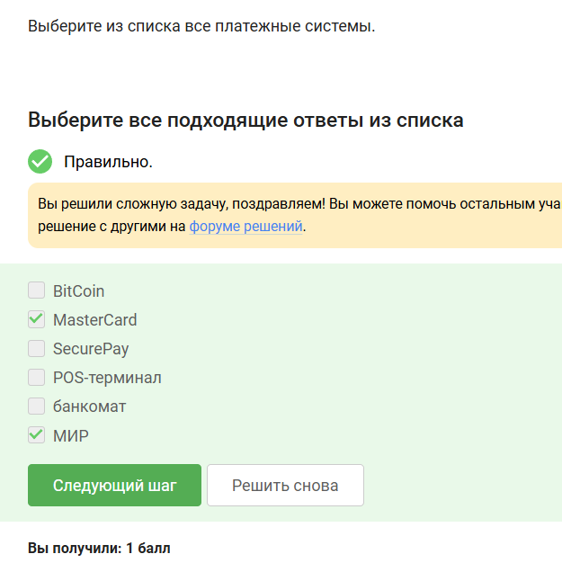

Рисунок 11: Платежные системы

## Примеры многофакторной аутентификации

Примеры многофакторной аутентификации: комбинация проверки пароля и кода в sms сообщении, комбинация кода в sms сообщении и отпечатка пальца (рис. 12).

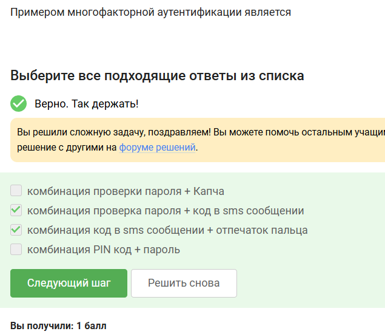

Рисунок 12: Примеры многофакторной аутентификации

## Онлайн платежи и использование многофакторной аутентификации

При онлайн платежах сегодня используется многофакторная аутентификация покупателя перед банком-эмитентом (рис. 13).

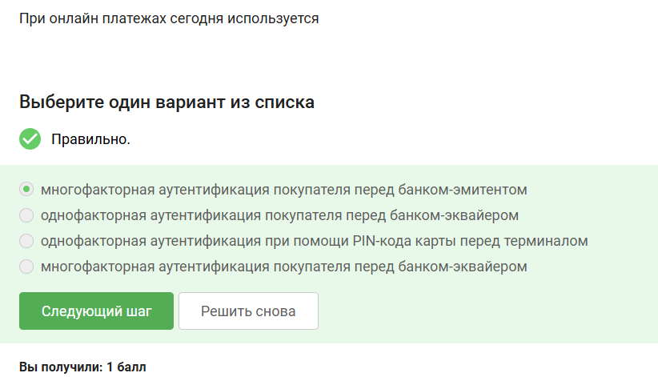

Рисунок 13: Онлайн платежи и использование многофакторной аутентификации

## Блокчейн. Свойство криптографической хэш-функции

Свойство криптографической хэш-функции, т е сложность нахождения прообраза, используется в доказательстве работы (рис. 14).

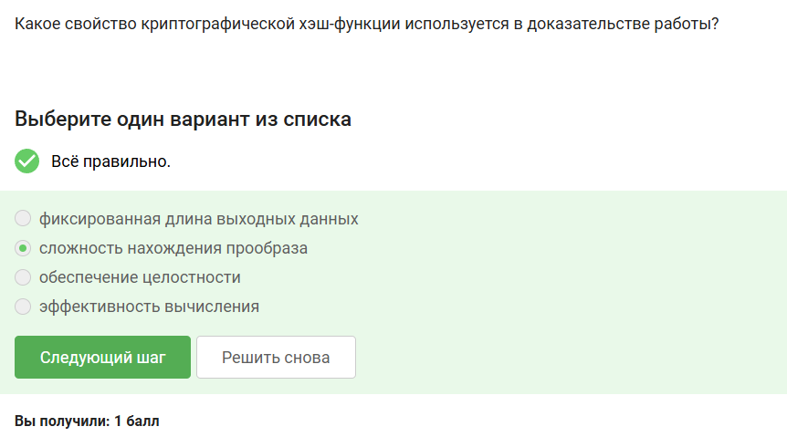

Рисунок 14: Свойство криптографической хэш-функции

## Консенсус в некоторых системах блокчейн

Консенсус в некоторых системах блокчейн обладает свойствами консенсуса, постоянства, живучести, открытости (рис. 15).

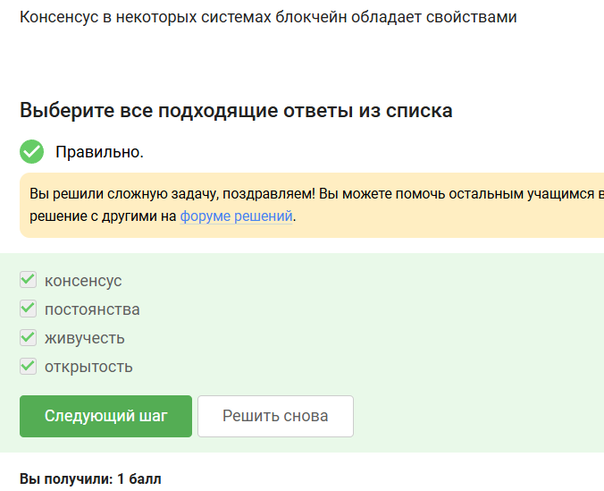

Рисунок 15: Консенсус в некоторых системах блокчейн

## Криптографический примитив

Участники блокчейна хранят секретные ключи криптографического примитива цифровой подписи (рис. 16).

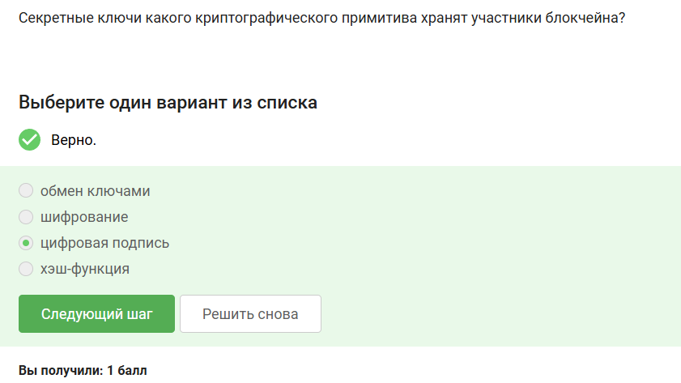

Рисунок 16: Криптографический примитив

# Выводы

В ходе прохождения раздела 3 внешнего курса были выполнены задания раздела 3 и была изучена тема криптографии на практике.

# Список литературы

1. И. Канта Б. им. Основы кибербезопасности: Внешний курс на платформе Stepik [Электронный ресурс]. Платформа Stepik. URL: https://stepik.org/111512 (дата обращения: 29.04.2026).